# Replication of Results from the Paper ’Unified implementation and comparison of Bayesian shrinkage methods for treatment effect estimation in subgroups`

All simulation results from the paper “Unified implementation and comparison of Bayesian shrinkage methods for treatment effect estimation in subgroups” (https://arxiv.org/abs/2603.21967) are stored at https://github.com/openpharma/bonsaiforest2/tree/main/simulations/paper.

This file replicates some of the tables from the paper.

# Results: Simulation for a time-to-event endpoint

## Standardized overall root mean squared error by simulation scenario

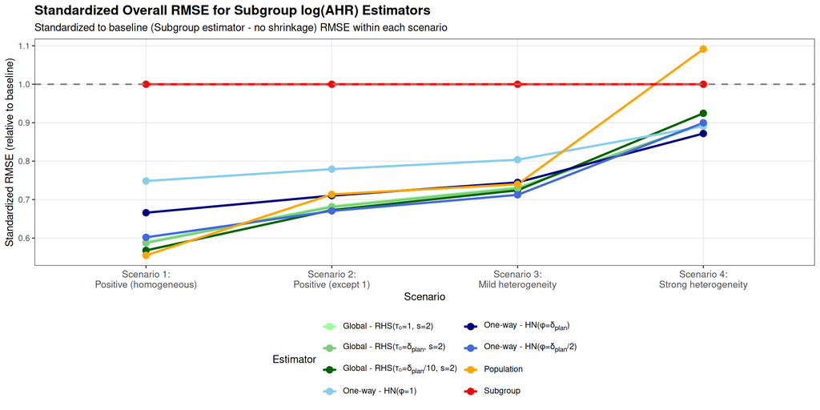

## Mean (range) of RMSE, bias, and observed coverage of nominal 95% confidence or credible intervals across subgroups by simulation scenario

TTE: Performance metrics (mean and range) by estimator and scenario

| Metric | Estimator | Scenario 1 | Scenario 2 | Scenario 3 | Scenario 4 |
| --- | --- | --- | --- | --- | --- |
| RMSE |  |  |  |  |  |
|  | Global - RHS(τ₀=1, s=2) | 0.14 (0.13-0.15) | 0.16 (0.13-0.28) | 0.16 (0.13-0.27) | 0.20 (0.13-0.37) |
|  | Global - RHS(τ₀=δ<sub>plan</sub>, s=2) | 0.14 (0.13-0.15) | 0.16 (0.13-0.29) | 0.16 (0.13-0.27) | 0.20 (0.13-0.38) |
|  | Global - RHS(τ₀=δ<sub>plan</sub>/10, s=2) | 0.13 (0.13-0.14) | 0.15 (0.13-0.31) | 0.16 (0.13-0.28) | 0.20 (0.13-0.41) |
|  | One-way - HN(φ=1) | 0.17 (0.14-0.23) | 0.18 (0.14-0.23) | 0.18 (0.14-0.26) | 0.20 (0.14-0.34) |
|  | One-way - HN(φ=δ<sub>plan</sub>) | 0.16 (0.14-0.19) | 0.17 (0.14-0.24) | 0.17 (0.13-0.25) | 0.19 (0.14-0.35) |
|  | One-way - HN(φ=δ<sub>plan</sub>/2) | 0.14 (0.13-0.15) | 0.15 (0.13-0.28) | 0.16 (0.13-0.26) | 0.20 (0.13-0.39) |
|  | Population | 0.13 (0.13-0.13) | 0.15 (0.13-0.41) | 0.16 (0.13-0.31) | 0.23 (0.13-0.53) |
|  | Subgroup | 0.23 (0.15-0.36) | 0.23 (0.15-0.35) | 0.22 (0.14-0.34) | 0.23 (0.14-0.34) |
| Absolute Bias |  |  |  |  |  |
|  | Global - RHS(τ₀=1, s=2) | 0.00 (0.00-0.01) | 0.03 (0.00-0.19) | 0.06 (0.00-0.20) | 0.07 (0.00-0.26) |
|  | Global - RHS(τ₀=δ<sub>plan</sub>, s=2) | 0.00 (0.00-0.01) | 0.03 (0.00-0.20) | 0.06 (0.00-0.20) | 0.08 (0.00-0.28) |
|  | Global - RHS(τ₀=δ<sub>plan</sub>/10, s=2) | 0.00 (0.00-0.01) | 0.03 (0.01-0.24) | 0.07 (0.00-0.23) | 0.10 (0.00-0.33) |
|  | One-way - HN(φ=1) | 0.01 (0.00-0.02) | 0.01 (0.00-0.09) | 0.03 (0.00-0.13) | 0.05 (0.00-0.19) |
|  | One-way - HN(φ=δ<sub>plan</sub>) | 0.00 (0.00-0.01) | 0.02 (0.00-0.14) | 0.04 (0.00-0.16) | 0.07 (0.00-0.26) |
|  | One-way - HN(φ=δ<sub>plan</sub>/2) | 0.00 (0.00-0.01) | 0.02 (0.00-0.22) | 0.06 (0.00-0.20) | 0.10 (0.00-0.35) |
|  | Population | 0.00 (0.00-0.01) | 0.04 (0.00-0.39) | 0.08 (0.00-0.29) | 0.16 (0.00-0.52) |
|  | Subgroup | 0.01 (0.00-0.02) | 0.01 (0.00-0.02) | 0.01 (0.00-0.02) | 0.01 (0.00-0.02) |
| Coverage |  |  |  |  |  |
|  | Global - RHS(τ₀=1, s=2) | 96% (94%-98%) | 95% (81%-99%) | 94% (84%-98%) | 93% (81%-97%) |
|  | Global - RHS(τ₀=δ<sub>plan</sub>, s=2) | 97% (95%-98%) | 95% (81%-98%) | 94% (83%-98%) | 92% (79%-97%) |
|  | Global - RHS(τ₀=δ<sub>plan</sub>/10, s=2) | 96% (95%-98%) | 94% (73%-98%) | 92% (76%-98%) | 90% (71%-97%) |
|  | One-way - HN(φ=1) | 97% (95%-99%) | 96% (93%-99%) | 96% (94%-98%) | 95% (88%-98%) |
|  | One-way - HN(φ=δ<sub>plan</sub>) | 97% (95%-99%) | 96% (89%-99%) | 96% (92%-98%) | 94% (83%-98%) |
|  | One-way - HN(φ=δ<sub>plan</sub>/2) | 97% (95%-99%) | 96% (82%-99%) | 95% (86%-98%) | 91% (68%-98%) |
|  | Population | 95% (95%-95%) | 88% (15%-95%) | 86% (39%-94%) | 70% (2%-94%) |
|  | Subgroup | 95% (93%-96%) | 95% (94%-96%) | 95% (94%-97%) | 95% (94%-97%) |

## Performance of estimators in subgroup 4a for scenario 2 where the drug does not work

TTE Scenario 2: Performance Metrics for Subgroup 4a (Worst Subgroup, AHR=1.00)

[output not shown]

## Accuracy of correctly identifying the worst subgroup as subgroup 4a for scenario 2

TTE Scenario 2: Accuracy of Identifying Subgroup 4a as the Worst Subgroup

[output not shown]

Accuracy shows the proportion of 1,000 replications where each estimator correctly identified subgroup 4a as the worst (highest AHR/least beneficial treatment effect).

# Results (including covariate-adjusted estimators): Simulation for a continuous endpoint

## Standardized overall root mean squared error by simulation scenario

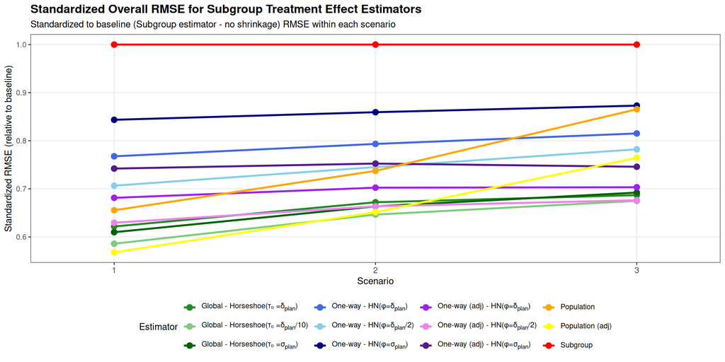

## Mean (range) of RMSE, bias, and observed coverage of nominal 95% confidence or credible intervals across subgroups by simulation scenario

Continuous: Performance metrics (mean and range) by estimator and scenario

| Metric | Estimator | Scenario 1 | Scenario 2 | Scenario 3 |
| --- | --- | --- | --- | --- |
| RMSE |  |  |  |  |
|  | Global - Horseshoe(τ₀ =δ<sub>plan</sub>) | 0.10 (0.09-0.11) | 0.11 (0.10-0.15) | 0.12 (0.10-0.17) |
|  | Global - Horseshoe(τ₀ =δ<sub>plan</sub>/10) | 0.09 (0.09-0.10) | 0.11 (0.10-0.16) | 0.12 (0.10-0.20) |
|  | Global - Horseshoe(τ₀ =σ<sub>plan</sub>) | 0.10 (0.09-0.10) | 0.11 (0.10-0.15) | 0.12 (0.10-0.18) |
|  | One-way - HN(φ=δ<sub>plan</sub>) | 0.12 (0.11-0.14) | 0.13 (0.11-0.15) | 0.14 (0.12-0.17) |
|  | One-way - HN(φ=δ<sub>plan</sub>/2) | 0.11 (0.10-0.12) | 0.12 (0.11-0.15) | 0.13 (0.12-0.19) |
|  | One-way - HN(φ=σ<sub>plan</sub>) | 0.13 (0.11-0.16) | 0.14 (0.12-0.17) | 0.15 (0.13-0.18) |
|  | One-way (adj) - HN(φ=δ<sub>plan</sub>) | 0.11 (0.10-0.12) | 0.12 (0.10-0.13) | 0.12 (0.11-0.15) |
|  | One-way (adj) - HN(φ=δ<sub>plan</sub>/2) | 0.10 (0.09-0.11) | 0.11 (0.10-0.14) | 0.12 (0.10-0.17) |
|  | One-way (adj) - HN(φ=σ<sub>plan</sub>) | 0.12 (0.10-0.14) | 0.12 (0.11-0.14) | 0.13 (0.11-0.15) |
|  | Population | 0.10 (0.10-0.10) | 0.12 (0.11-0.19) | 0.15 (0.12-0.34) |
|  | Population (adj) | 0.09 (0.09-0.09) | 0.11 (0.09-0.19) | 0.13 (0.10-0.34) |
|  | Subgroup | 0.16 (0.12-0.23) | 0.16 (0.13-0.23) | 0.17 (0.14-0.24) |
| Absolute Bias |  |  |  |  |
|  | Global - Horseshoe(τ₀ =δ<sub>plan</sub>) | 0.00 (0.00-0.00) | 0.01 (0.00-0.08) | 0.01 (0.00-0.06) |
|  | Global - Horseshoe(τ₀ =δ<sub>plan</sub>/10) | 0.00 (0.00-0.00) | 0.02 (0.00-0.11) | 0.02 (0.00-0.11) |
|  | Global - Horseshoe(τ₀ =σ<sub>plan</sub>) | 0.00 (0.00-0.00) | 0.02 (0.00-0.09) | 0.02 (0.00-0.08) |
|  | One-way - HN(φ=δ<sub>plan</sub>) | 0.00 (0.00-0.01) | 0.01 (0.00-0.06) | 0.02 (0.00-0.07) |
|  | One-way - HN(φ=δ<sub>plan</sub>/2) | 0.00 (0.00-0.01) | 0.02 (0.00-0.09) | 0.03 (0.00-0.12) |
|  | One-way - HN(φ=σ<sub>plan</sub>) | 0.00 (0.00-0.01) | 0.01 (0.00-0.04) | 0.01 (0.00-0.03) |
|  | One-way (adj) - HN(φ=δ<sub>plan</sub>) | 0.00 (0.00-0.00) | 0.01 (0.00-0.05) | 0.02 (0.00-0.06) |
|  | One-way (adj) - HN(φ=δ<sub>plan</sub>/2) | 0.00 (0.00-0.00) | 0.02 (0.00-0.08) | 0.02 (0.00-0.10) |
|  | One-way (adj) - HN(φ=σ<sub>plan</sub>) | 0.00 (0.00-0.01) | 0.01 (0.00-0.03) | 0.01 (0.00-0.03) |
|  | Population | 0.00 (0.00-0.00) | 0.03 (0.00-0.16) | 0.06 (0.00-0.32) |
|  | Population (adj) | 0.00 (0.00-0.00) | 0.03 (0.00-0.16) | 0.06 (0.00-0.32) |
|  | Subgroup | 0.00 (0.00-0.01) | 0.00 (0.00-0.01) | 0.00 (0.00-0.01) |
| Coverage |  |  |  |  |
|  | Global - Horseshoe(τ₀ =δ<sub>plan</sub>) | 97% (96%-98%) | 96% (90%-98%) | 95% (91%-97%) |
|  | Global - Horseshoe(τ₀ =δ<sub>plan</sub>/10) | 97% (96%-98%) | 95% (85%-97%) | 94% (85%-96%) |
|  | Global - Horseshoe(τ₀ =σ<sub>plan</sub>) | 97% (96%-98%) | 96% (89%-98%) | 95% (88%-97%) |
|  | One-way - HN(φ=δ<sub>plan</sub>) | 97% (96%-98%) | 96% (93%-98%) | 96% (92%-98%) |
|  | One-way - HN(φ=δ<sub>plan</sub>/2) | 98% (96%-98%) | 96% (91%-98%) | 95% (88%-98%) |
|  | One-way - HN(φ=σ<sub>plan</sub>) | 97% (96%-98%) | 96% (94%-98%) | 96% (94%-98%) |
|  | One-way (adj) - HN(φ=δ<sub>plan</sub>) | 97% (96%-98%) | 96% (94%-98%) | 96% (92%-98%) |
|  | One-way (adj) - HN(φ=δ<sub>plan</sub>/2) | 97% (96%-99%) | 96% (91%-98%) | 95% (88%-98%) |
|  | One-way (adj) - HN(φ=σ<sub>plan</sub>) | 97% (95%-98%) | 96% (95%-98%) | 96% (93%-97%) |
|  | Population | 96% (96%-96%) | 91% (70%-95%) | 84% (19%-95%) |
|  | Population (adj) | 95% (95%-95%) | 90% (62%-95%) | 82% (8%-95%) |
|  | Subgroup | 95% (94%-96%) | 95% (93%-96%) | 94% (93%-95%) |

## Performance of estimators in subgroup X11cat.a for scenario 3 with the worst observed efficacy

Continuous Scenario 3: Performance Metrics for X11cat level a (Worst Subgroup)

| Estimator | RMSE | Absolute Bias | 95% CI Coverage |
| --- | --- | --- | --- |
| Global - Horseshoe(τ₀ =δ<sub>plan</sub>) | 0.16 | 0.05 | 91% |
| Global - Horseshoe(τ₀ =δ<sub>plan</sub>/10) | 0.19 | 0.10 | 86% |
| Global - Horseshoe(τ₀ =σ<sub>plan</sub>) | 0.17 | 0.07 | 89% |
| One-way (adj) - HN(φ=δ<sub>plan</sub>) | 0.15 | 0.05 | 92% |
| One-way (adj) - HN(φ=δ<sub>plan</sub>/2) | 0.16 | 0.09 | 89% |
| One-way (adj) - HN(φ=σ<sub>plan</sub>) | 0.14 | 0.02 | 93% |
| One-way - HN(φ=δ<sub>plan</sub>) | 0.16 | 0.06 | 92% |
| One-way - HN(φ=δ<sub>plan</sub>/2) | 0.18 | 0.11 | 88% |
| One-way - HN(φ=σ<sub>plan</sub>) | 0.16 | 0.03 | 94% |
| Population | 0.33 | 0.30 | 24% |
| Population (adj) | 0.32 | 0.30 | 12% |
| Subgroup | 0.15 | 0.00 | 94% |

## Accuracy of correctly identifying the worst subgroup as subgroup X11cat.a for scenario 3

Continuous Scenario 3: Accuracy of Identifying X11cat level a as the Worst Subgroup

| Estimator | Replications | Correct Identifications | Accuracy (%) |
| --- | --- | --- | --- |
| Global - Horseshoe(τ₀ =δ<sub>plan</sub>) | 1000 | 893 | 89% |
| Global - Horseshoe(τ₀ =δ<sub>plan</sub>/10) | 1000 | 903 | 90% |
| Global - Horseshoe(τ₀ =σ<sub>plan</sub>) | 1000 | 895 | 90% |
| One-way (adj) - HN(φ=δ<sub>plan</sub>) | 1000 | 888 | 89% |
| One-way (adj) - HN(φ=δ<sub>plan</sub>/2) | 1000 | 893 | 89% |
| One-way (adj) - HN(φ=σ<sub>plan</sub>) | 1000 | 872 | 87% |
| One-way - HN(φ=δ<sub>plan</sub>) | 1000 | 791 | 79% |
| One-way - HN(φ=δ<sub>plan</sub>/2) | 1000 | 787 | 79% |
| One-way - HN(φ=σ<sub>plan</sub>) | 1000 | 769 | 77% |
| Subgroup | 1000 | 695 | 70% |

Accuracy shows the proportion of 1,000 replications where each estimator correctly identified X11cat=a as the worst (smallest absolute treatment effect - closest to 0).

# Supplementary: Results for global models with a normal prior and a half-normal hyperprior for the standard deviation

## Simulations for a time-to-event endpoint

TTE Supplementary: Global HN models - Overall RMSE and mean (range) of bias across all replications and subgroups

| Scenario | Estimator | RMSE | \|Bias\| | Coverage |
| --- | --- | --- | --- | --- |
| 1 | Global - HN(φ=1) | 0.14 (0.13-0.15) | 0.00 (0.00-0.01) | 97% (95%-99%) |
|  | Global - HN(φ=δ<sub>plan</sub>) | 0.14 (0.13-0.14) | 0.00 (0.00-0.01) | 97% (95%-99%) |
|  | Global - HN(φ=δ<sub>plan</sub>/2) | 0.14 (0.13-0.14) | 0.00 (0.00-0.01) | 97% (94%-98%) |
| 2 | Global - HN(φ=1) | 0.16 (0.13-0.29) | 0.03 (0.00-0.24) | 95% (74%-99%) |
|  | Global - HN(φ=δ<sub>plan</sub>) | 0.16 (0.13-0.30) | 0.03 (0.01-0.25) | 95% (72%-99%) |
|  | Global - HN(φ=δ<sub>plan</sub>/2) | 0.16 (0.13-0.31) | 0.04 (0.01-0.27) | 94% (65%-99%) |
| 3 | Global - HN(φ=1) | 0.16 (0.13-0.26) | 0.06 (0.00-0.20) | 94% (83%-98%) |
|  | Global - HN(φ=δ<sub>plan</sub>) | 0.16 (0.13-0.26) | 0.06 (0.00-0.20) | 94% (82%-98%) |
|  | Global - HN(φ=δ<sub>plan</sub>/2) | 0.16 (0.13-0.27) | 0.06 (0.00-0.22) | 94% (80%-98%) |
| 4 | Global - HN(φ=1) | 0.19 (0.13-0.33) | 0.07 (0.00-0.26) | 93% (82%-97%) |
|  | Global - HN(φ=δ<sub>plan</sub>) | 0.19 (0.13-0.34) | 0.07 (0.00-0.27) | 93% (80%-98%) |
|  | Global - HN(φ=δ<sub>plan</sub>/2) | 0.19 (0.13-0.36) | 0.08 (0.00-0.31) | 92% (75%-98%) |

## Simulations for a continuous endpoint

Continuous Supplementary: Global HN models - Overall RMSE and mean (range) of bias across all replications and subgroups

| Scenario | Estimator | RMSE | \|Bias\| | Coverage |
| --- | --- | --- | --- | --- |
| 1 | Global - HN(φ=δ<sub>plan</sub>) | 0.10 (0.09-0.10) | 0.00 (0.00-0.00) | 97% (96%-99%) |
|  | Global - HN(φ=δ<sub>plan</sub>/2) | 0.10 (0.09-0.10) | 0.00 (0.00-0.00) | 97% (96%-98%) |
|  | Global - HN(φ=σ<sub>plan</sub>) | 0.10 (0.09-0.10) | 0.00 (0.00-0.00) | 97% (96%-99%) |
| 2 | Global - HN(φ=δ<sub>plan</sub>) | 0.11 (0.10-0.15) | 0.02 (0.00-0.10) | 96% (88%-98%) |
|  | Global - HN(φ=δ<sub>plan</sub>/2) | 0.11 (0.10-0.15) | 0.02 (0.00-0.10) | 95% (86%-98%) |
|  | Global - HN(φ=σ<sub>plan</sub>) | 0.11 (0.10-0.14) | 0.02 (0.00-0.09) | 96% (89%-98%) |
| 3 | Global - HN(φ=δ<sub>plan</sub>) | 0.13 (0.10-0.19) | 0.02 (0.00-0.14) | 94% (82%-97%) |
|  | Global - HN(φ=δ<sub>plan</sub>/2) | 0.12 (0.10-0.20) | 0.03 (0.00-0.16) | 94% (78%-98%) |
|  | Global - HN(φ=σ<sub>plan</sub>) | 0.13 (0.10-0.19) | 0.02 (0.00-0.13) | 94% (83%-98%) |

**Document generated**: 2026-03-24 19:24:29.486092